## Présentation hdf5

### T.Robert - titouan.robert@datastorm.fr

### Meetup R Addict Paris - 16/01/2020

[figure not shown]

## Introduction au stockage

Il existe deux formes de stockage :

- Les fichiers textes : l’information est stockée sous forme de caractères lisibles par un éditeur de texte principalement des lettres et des chiffres (csv, txt)
- Les fichiers binaires : l’information est stockée en binaire une suite d’octets dont la valeur est comprise entre 0x00 et 0xFF (rds, h5)

Les fichiers binaires sont moins corruptibles, (amère expérience sur un fichier de backup en csv).

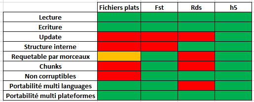

## Présentation de HDF5

- Un stockage local -> Un fichier pas de base de données
- Des fichiers binaires (extension h5)
- Des fichiers structurés
- Possibilité de stocker :
  - vecteur
  - matrice
  - tenseur (tableau 3D)
- Un stockage local (pas de BDD)
- Le plus rapide que j’ai trouvé pour des tenseurs volumineux
- Utilisé par tensorflow (potentiellement beaucoups de coefficients > 10^6)
- Possibilité de compresser les données

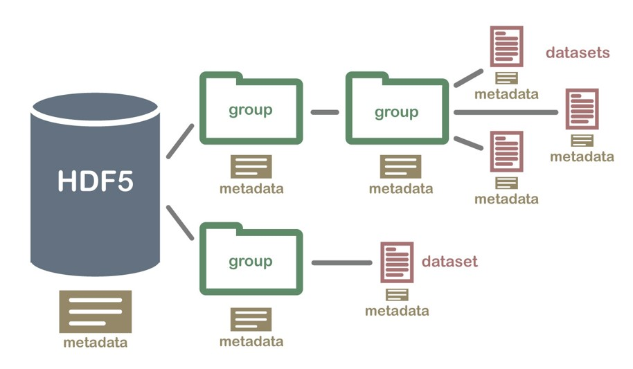

## h5, visualisation et structure

**HDFView** : un petit outil pour visualiser vos fichier h5.

https://support.hdfgroup.org/products/java/release/download.html#bin

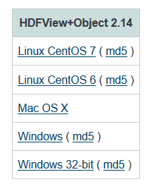

- Permet une exploration rapide des fichiers
- Facile d’utilisation

[figure not shown]

## Le package rhdf5

**Disponible uniquement sur bioconductor**

Un tuto sympa : https://www.bioconductor.org/packages/release/bioc/vignettes/rhdf5/inst/doc/rhdf5.html

### D’autres choix

h5 **¤¤** hdf5r **¤¤** hdfqlr

rhdf5 à l’avantage d’être bien intégré, stable (ancienneté), et maintenu à jour

### Installation

```r
install.packages("BiocManager")
BiocManager::install("rhdf5")
```

### Création d’un fichier

```r
library(rhdf5)
h5createFile("myhdf5file.h5")
```

## Création de structure et écriture d’objets

### Création de groupe / sous groupes

- Les groupes et sous-groupes servent pour structurer nos données.
- Liste récursive (comme dans **R** ou **json**)

```r
h5createGroup("myhdf5file.h5","G1")
h5createGroup("myhdf5file.h5","G2")
h5createGroup("myhdf5file.h5","G1/G11")
```

### La fonction *h5ls* : visualiser sa structure.

```r
h5ls("myhdf5file.h5")
```

```
##   group name     otype dclass dim
## 0     /   G1 H5I_GROUP
## 1   /G1  G11 H5I_GROUP
## 2     /   G2 H5I_GROUP
```

### Ecriture d’objets

```r
V <- LETTERS # Write a vector
h5write(V, "myhdf5file.h5", "G1/V") # Write a matrix
A <- matrix(1:10, nr = 5, nc = 2)
h5write(A, "myhdf5file.h5", "G2/A") # Write a data.frame
dfd <- data.frame(A = 1L:5L, B = seq(0, 1, length.out = 5),
                C = c("ab", "cde", "fghi", "a", "s"),
               stringsAsFactors = FALSE)
h5write(dfd, "myhdf5file.h5", "df") # Write a tensor
tensor <- array(1:8, c(2, 2, 2))
h5write(tensor, "myhdf5file.h5", "tensor")
h5ls("myhdf5file.h5")
```

```
##   group   name       otype   dclass       dim
## 0     /     G1   H5I_GROUP
## 1   /G1    G11   H5I_GROUP
## 2   /G1      V H5I_DATASET   STRING        26
## 3     /     G2   H5I_GROUP
## 4   /G2      A H5I_DATASET  INTEGER     5 x 2
## 5     /     df H5I_DATASET COMPOUND         5
## 6     / tensor H5I_DATASET  INTEGER 2 x 2 x 2
```

## Lecture d’objet

### Accès avec une ouverture de connection

```r
h5f <- H5Fopen("myhdf5file.h5") #Création de la connection vers le fichier H5.
# Taille de l'objet 928 Bytes
# Accès aux objets
h5f$df ; h5f$G2$A[1:2,]
```

```
##   A    B    C
## 1 1 0.00   ab
## 2 2 0.25  cde
## 3 3 0.50 fghi
## 4 4 0.75    a
## 5 5 1.00    s
```

```
##      [,1] [,2]
## [1,]    1    6
## [2,]    2    7
```

```r
# Fermer la connection
H5Fclose(h5f)
```

Taille de **h5f** 928 bytes Taille de **h5f$df** 1896 bytes

### Accès sans ouverture de connection

```r
h5read("myhdf5file.h5", "G2/A")
```

```
##      [,1] [,2]
## [1,]    1    6
## [2,]    2    7
## [3,]    3    8
## [4,]    4    9
## [5,]    5   10
```

D’un avis personnel :

- La première option est très utile dans un contexte d’exploration, **rapide** et **facile** à utiliser
- La seconde option est très utile dans une logique d’industrialisation, pas de fermeture de connection dons pas de bug en cas de plantage.

## Sous-parties d’objets

### Lecture

```r
h5read("myhdf5file.h5", "G2/A")
```

```
##      [,1] [,2]
## [1,]    1    6
## [2,]    2    7
## [3,]    3    8
## [4,]    4    9
## [5,]    5   10
```

```r
h5read("myhdf5file.h5", "G2/A", index = list(2:3,1:2))
```

```
##      [,1] [,2]
## [1,]    2    7
## [2,]    3    8
```

### Update

```r
h5write(matrix(151:154,nr = 2,nc = 2),
        file = "myhdf5file.h5",
        name = "G2/A",
        start = c(2,1))
h5read("myhdf5file.h5", "G2/A")
```

```
##      [,1] [,2]
## [1,]    1    6
## [2,]  151  153
## [3,]  152  154
## [4,]    4    9
## [5,]    5   10
```

## Fonctionnement des chunks

- Permettent de lire des **sous-parties** d’objet sans le parcourir en entier
- Doivent être définis judicieusement en fonction de l’utilisation
- Augmentent le temps d’écriture, mais réduisent le temps de lecture

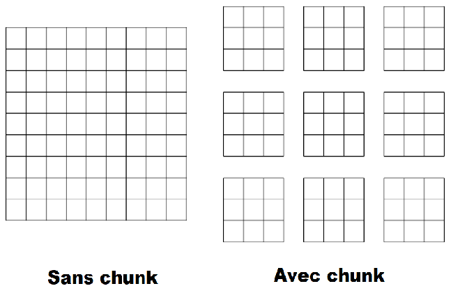

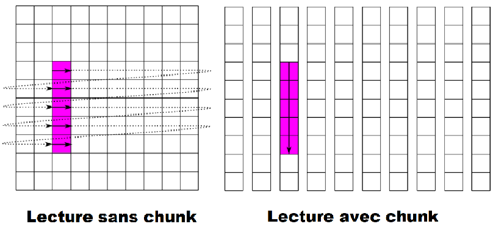

## Définition des chunks : *h5createDataset*

### Utilisation de l’argument chunk

```r
h5createDataset(file = "myhdf5file.h5", dataset = "G1/H",dims = c(1000, 1000 , 100),
                storage.mode = "integer", chunk = c(1000, 1, 1))
arr <- array(runif(1000 * 1000 * 100), c(1000, 1000, 100))
h5write(arr , file = "myhdf5file.h5", name = "G1/H", start = c(1, 1, 1))
H5close()
```

### Performance à la lecture

```r
library(microbenchmark)
mb <- microbenchmark(h5read("myhdf5file.h5", "G1/H", index = list(1:1000, 1, 1)),
                     h5read("myhdf5file.h5", "G1/H", index = list(1, 1:1000, 1)))
```

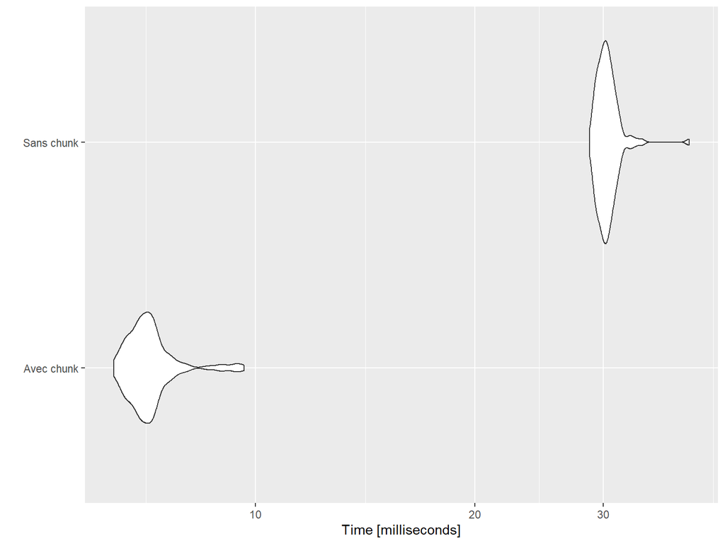

## Benchmark contre les fonction R les plus rapides

### Test en lecture force brute (matrice 10K * 10K)

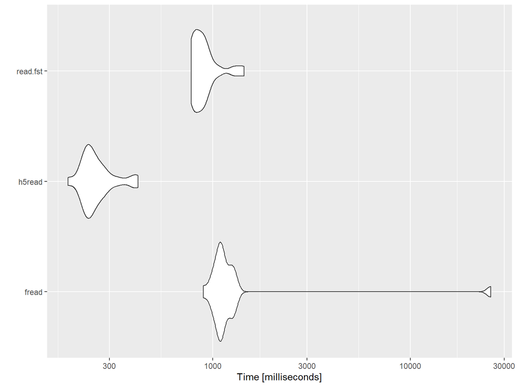

## Conclusion

- Un système rapide
- Utilisé par tensorflow (google)
- Repond à tous les besoins
- Bien intrégré sous R
- Non corruptible
- Multi plateforme

### Exemples d’utilisations

- Mise à jour des coefficients lors de l’apprentissage d’un reseau de neurones
- Branché à une application shiny pour garder de la réactivité avec de gros volumes de données (Antares, RTE)

[figure not shown]